# DSPostLiveAssignment11_TimeSeries, MSDS 6306 - 405

Mariana Llamas-Cendon

11/17/2016

```r
## Load library fpp
## Load data ukcars
library(fpp)
data(ukcars)
ukcars
```

```
##         Qtr1    Qtr2    Qtr3    Qtr4
## 1977 330.371 371.051 270.670 343.880
## 1978 358.491 362.822 261.281 240.355
## 1979 325.382 316.700 171.153 257.217
## 1980 298.127 251.464 181.555 192.598
## 1981 245.652 245.526 225.261 238.211
## 1982 257.385 228.461 175.371 226.462
## 1983 266.150 287.251 225.883 265.313
## 1984 272.759 234.134 196.462 205.551
## 1985 291.283 284.422 221.571 250.697
## 1986 253.757 267.016 220.388 277.801
## 1987 283.233 302.072 259.720 297.658
## 1988 306.129 322.106 256.723 341.877
## 1989 356.004 361.540 270.433 311.105
## 1990 326.688 327.059 274.257 367.606
## 1991 346.163 348.211 250.008 292.518
## 1992 343.318 343.429 275.386 329.747
## 1993 364.521 378.448 300.798 331.757
## 1994 362.536 389.133 323.322 391.832
## 1995 421.646 416.823 311.713 381.902
## 1996 422.982 427.722 376.850 458.580
## 1997 436.225 441.487 369.566 450.723
## 1998 462.442 468.232 403.636 413.948
## 1999 460.496 448.932 407.787 469.408
## 2000 494.311 433.240 335.106 378.795
## 2001 387.100 372.395 335.790 397.080
## 2002 449.755 402.252 391.847 385.890
## 2003 424.325 433.280 391.213 408.740
## 2004 445.458 428.202 379.048 394.042
## 2005 432.796
```

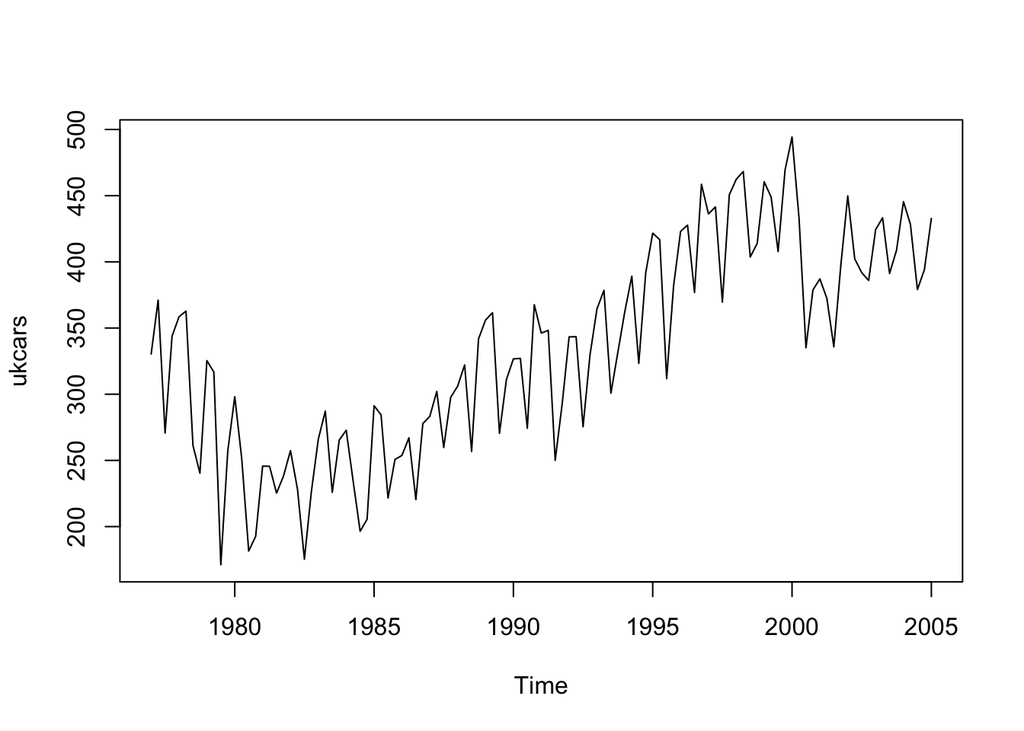

```r
## Plot data to explore and identify any evident trend
plot(ukcars)
```

##### Plot the time series. Can you identify seasonal fluctuations and/or a trend?

###### From the plot it is evident that the years previous to 1980 experienced a decline in the production of cars in the UK, but from 1980 to 2000 the trend was evidently upward. Nevertheless, we can see some regular patterns that appear to be peaks that would indicate seasonal value of about each year. One could argue that this due to the release of new models.

###### Also there is a dip fromm 500 to about 300 in the year 2000 that would need to be investigated further to figure out the situation that cause the sudden drop: if it was due to a bad economy, a recession or other causes that are not evident in the plot or just an error in how the data was gathered.

##### Use a classical decomposition to calculate the trend-cycle and seasonal indices.

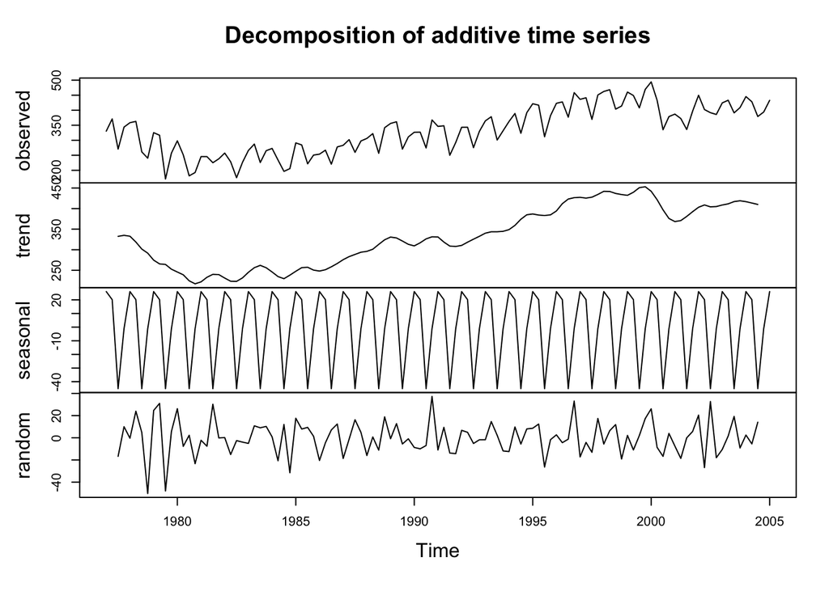

```r
## Using decompose we can find the seasonal value.
fitd <- decompose(ukcars)
plot(fitd)
```

#### Do the results support the graphical interpretation from part (a)?

###### Yes, by using decomposition seasonality becomes more evident. In the observed we can still see a peak a little over the year 2000 that can be considered as an outlier, which I am guessing represents the dip we saw when we first plotted the data, although after decomposing doesn’t seem as pronounced.

###### Decomposing as it was expected eliminated the beginning values from trend corresponding to Q1, Q2 from 1977; and the last two corresponding to Q4 of 2004, and Q1 of 2005.

#### Compute and plot the seasonally adjusted data.

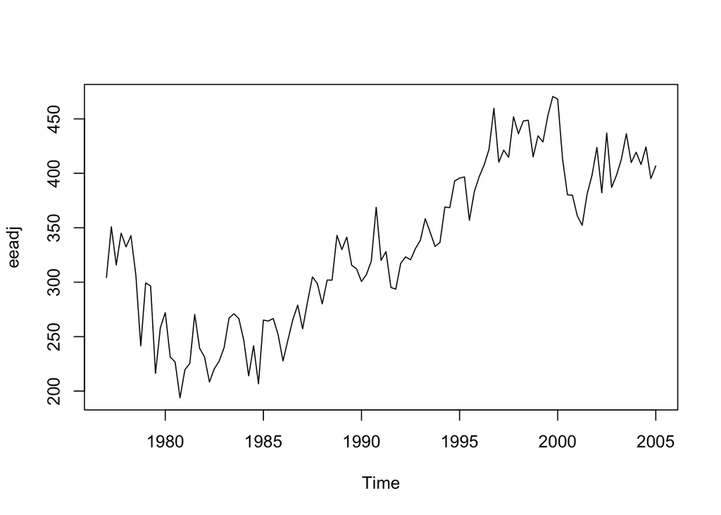

```r
eeadj <- seasadj(fitd)
plot(eeadj)
```

#### Change one observation to be an outlier (e.g., add 500 to one observation), and recompute the seasonally adjusted data. What is the effect of the outlier?

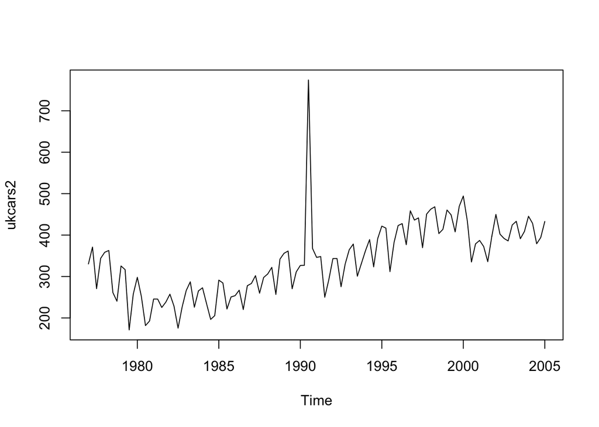

```r
ukcars2 <- ukcars
ukcars2[55] <- ukcars2[55]+500
plot(ukcars2)
```

```r
fitd2 <- decompose(ukcars2)
```

###### The effect of the outlier falls on a very specific date, and even though it affects the overall dimension of the data it doesn’t really change the trend of the seasonality from the rest of the dates.

#### Does it make any difference if the outlier is near the end rather than in the middle of the time series?

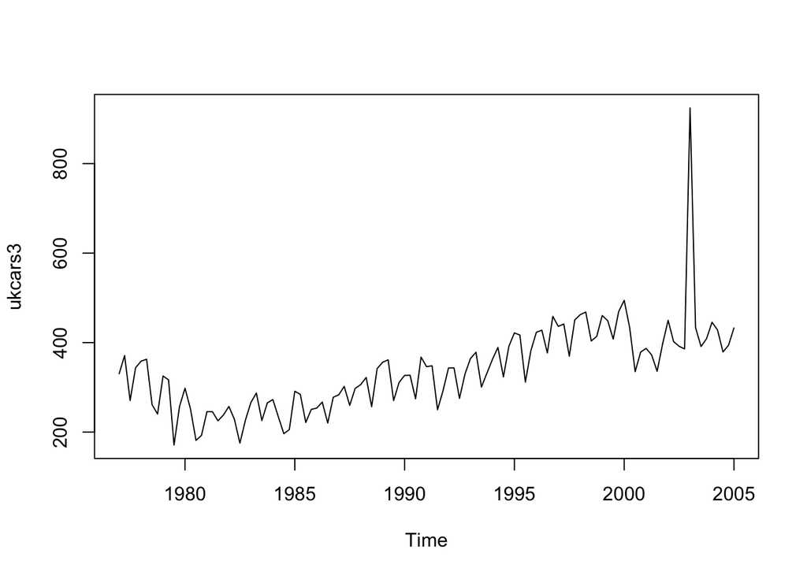

```r
ukcars3 <- ukcars
ukcars3[105] <- ukcars3[105]+500
plot(ukcars3)
```

```r
fitd3 <- decompose(ukcars3)
```

###### No, it really doesn’t make a difference in this dataset. It is just the magnitude that is affected, but the outlier still having an effect on a particular date (or in this case year), but doesn’t really change trends.

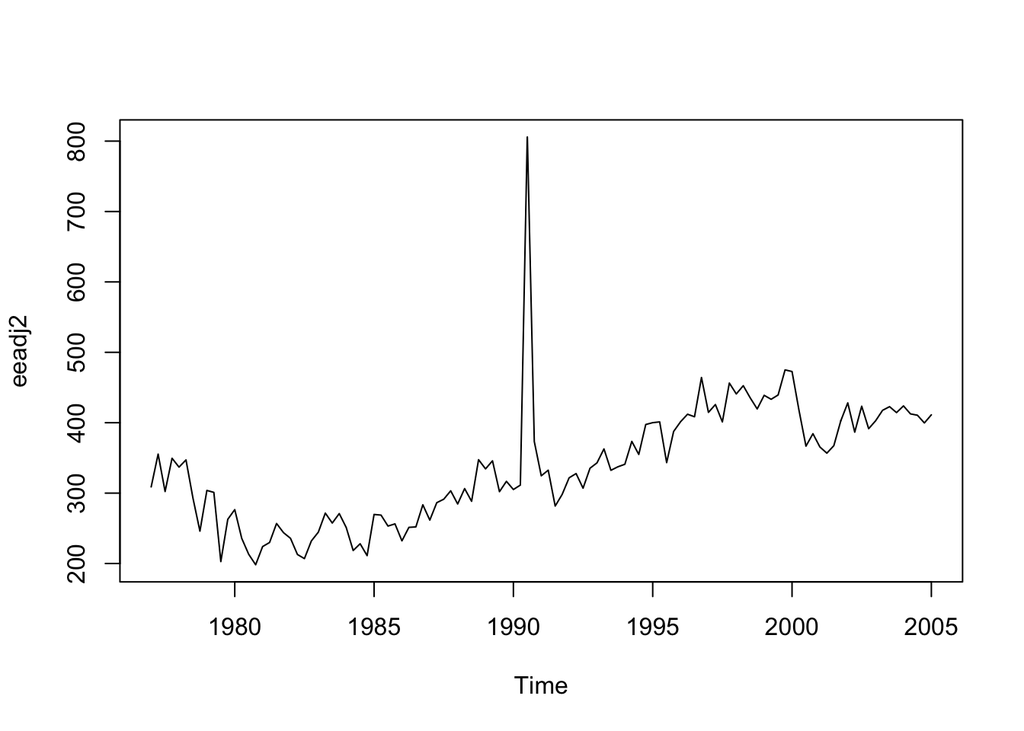

```r
eeadj2 <- seasadj(fitd2)
plot(eeadj2)
```

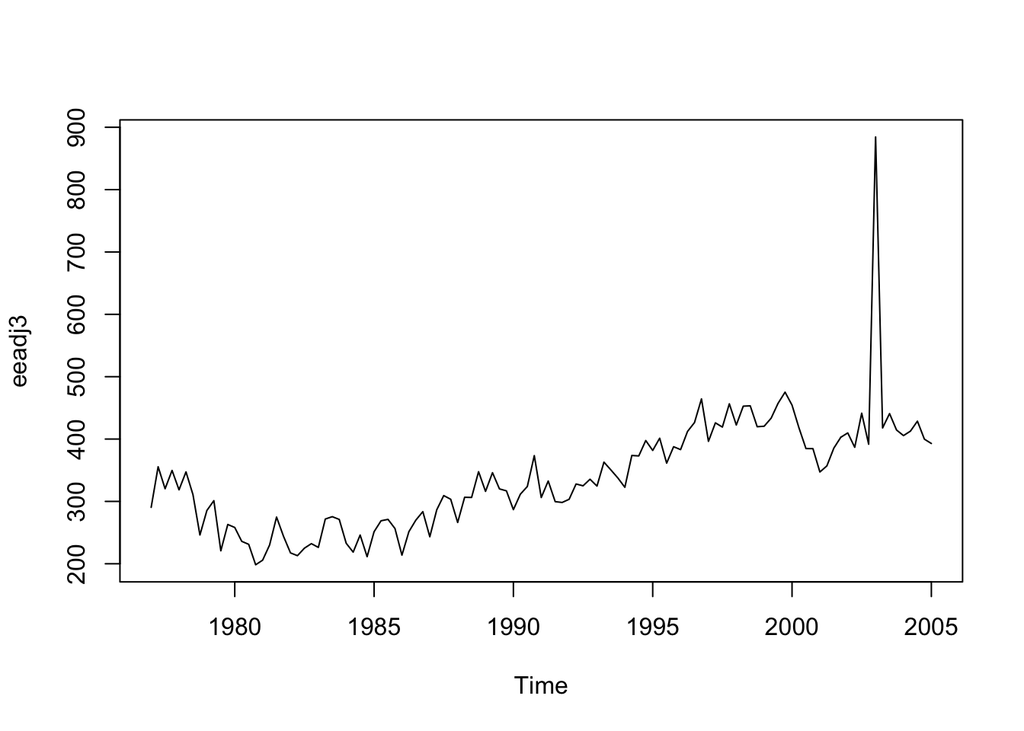

```r
eeadj3 <- seasadj(fitd3)
plot(eeadj3)
```

###### Readjusting the seasonal data, smooths the highs and lows, and therefore displays a more uniform behavior.

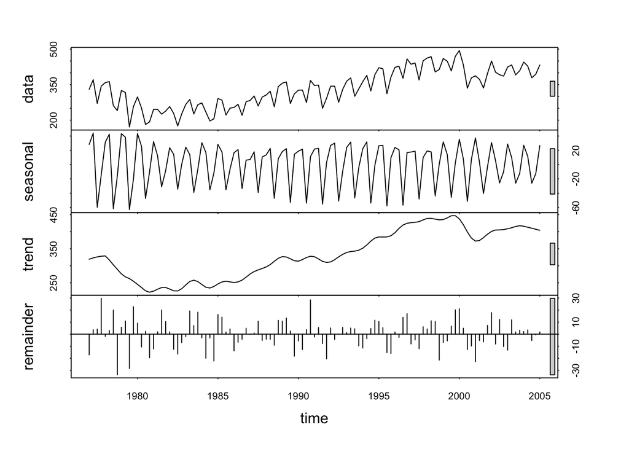

```r
ukcarsseas <- stl(ukcars, s.window=5)
plot(ukcarsseas)
```

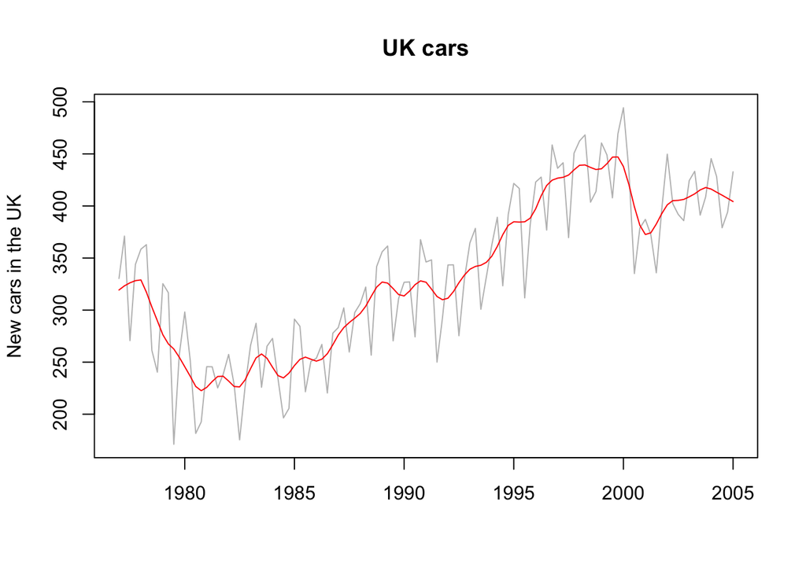

```r
fit <- stl(ukcars, s.window=5)
plot(ukcars, col="gray",
     main="UK cars",
     ylab="New cars in the UK", xlab="")
lines(fit$time.series[,2],col="red",ylab="Trend")
```